# LobLaw

```python
import numpy as np
import pandas as pd
import seaborn as sns
import matplotlib.pyplot as plt
from sklearn.model_selection import train_test_split
from sklearn.preprocessing import LabelEncoder
from sklearn.metrics import accuracy_score, confusion_matrix, classification_report, roc_auc_score
from sklearn.ensemble import RandomForestClassifier
from xgboost import XGBClassifier
from sklearn.feature_selection import SelectKBest, f_classif, chi2, RFE, SelectFromModel  # SelectFromModel'ı burada import ediyoruz
from sklearn.model_selection import GridSearchCV
from sklearn.neighbors import KNeighborsClassifier
from sklearn.linear_model import LogisticRegression
import shap

# Load the Excel file
xlsx = pd.ExcelFile(r"C:\Users\Admin\Documents\MLAI\CSCN8030\Proje_Loblaw\loblaws.xlsx")

# Load the data
Data_dict = pd.read_excel(xlsx, xlsx.sheet_names[0], header=1)
data = pd.read_excel(xlsx, xlsx.sheet_names[1], header=0)
```

```python
# Drop missing values
data = data.dropna()

# Convert categorical features to numerical
categorical_features = data.select_dtypes(include=['object']).columns.tolist()

# Display unique values for categorical features
for feature in categorical_features:
    print(f"{feature}:")
    print('\t' + str(data[feature].unique()))

# Replace values for consistency
category_mapping = {
    'PreferredLoginDevice': {'Mobile Phone': 'Phone'},
    'PreferredPaymentMode': {'COD': 'Cash on Delivery', 'CC': 'Credit Card'},
    'PreferedOrderCat': {'Mobile': 'Mobile Phone'}
}

for col, mapping in category_mapping.items():
    data[col] = data[col].replace(mapping)

# Encode categorical features
for feature in categorical_features:
    label_encoder = LabelEncoder()
    data[feature] = label_encoder.fit_transform(data[feature])

# Verify the changes
for feature in categorical_features:
    print(f"{feature}:")
    print('\t' + str(data[feature].unique()))
```

```
PreferredLoginDevice:
	['Mobile Phone' 'Phone' 'Computer']
PreferredPaymentMode:
	['Debit Card' 'COD' 'CC' 'Credit Card' 'E wallet' 'UPI' 'Cash on Delivery']
Gender:
	['Female' 'Male']
PreferedOrderCat:
	['Laptop & Accessory' 'Mobile Phone' 'Fashion' 'Mobile' 'Others' 'Grocery']
MaritalStatus:
	['Single' 'Divorced' 'Married']
PreferredLoginDevice:
	[1 0]
PreferredPaymentMode:
	[2 0 1 3 4]
Gender:
	[0 1]
PreferedOrderCat:
	[2 3 0 4 1]
MaritalStatus:
	[2 0 1]
```

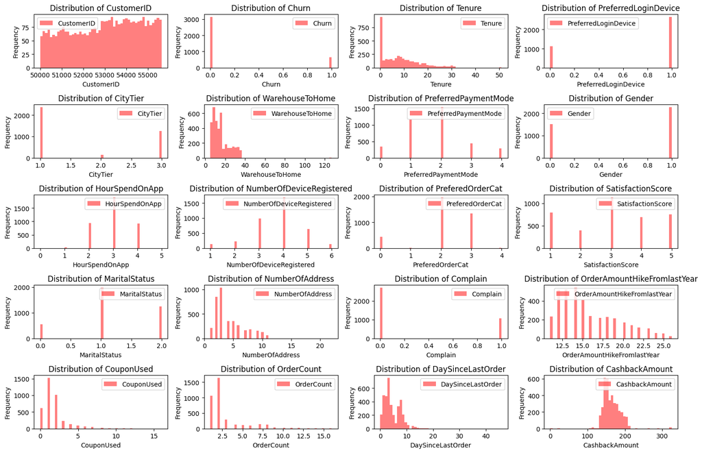

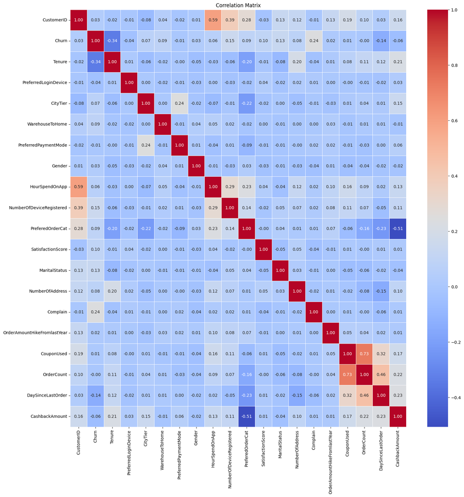

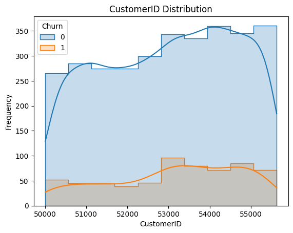

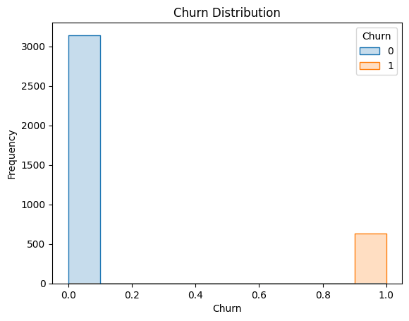

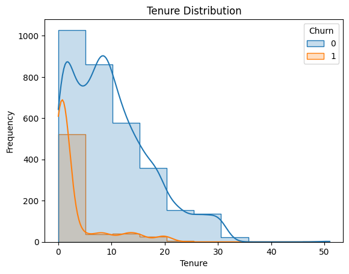

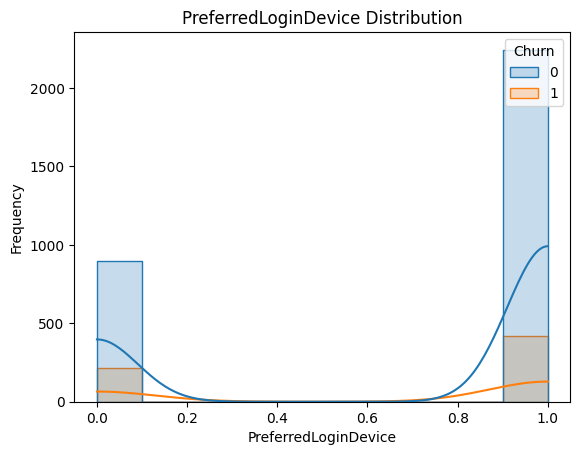

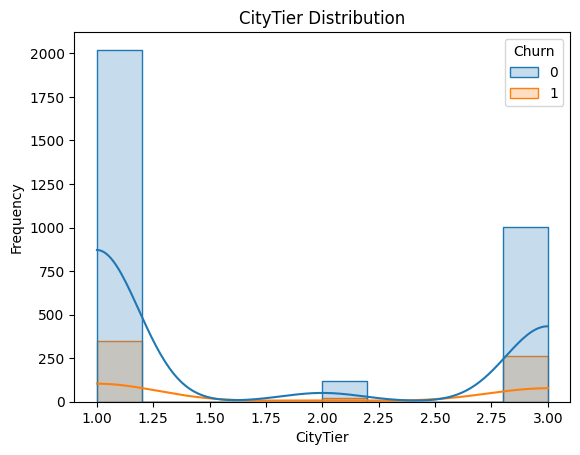

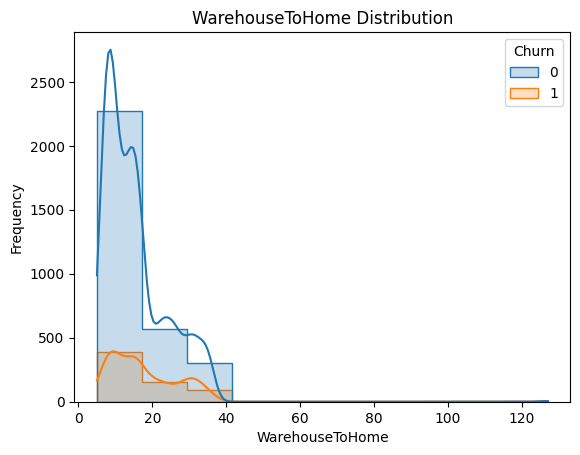

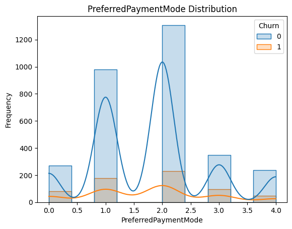

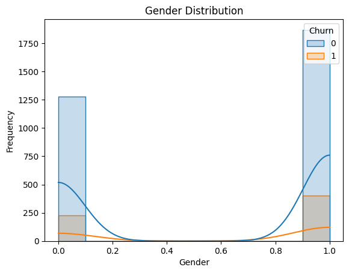

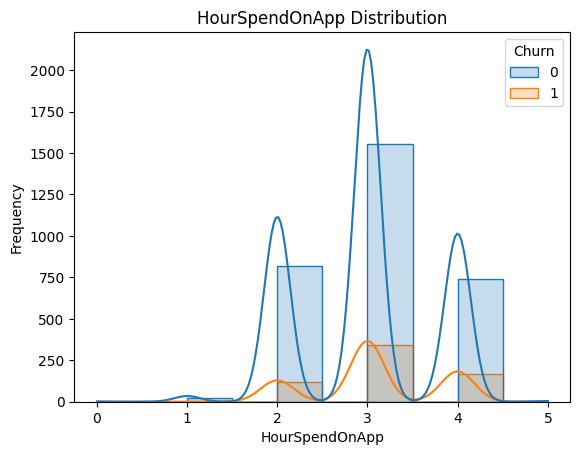

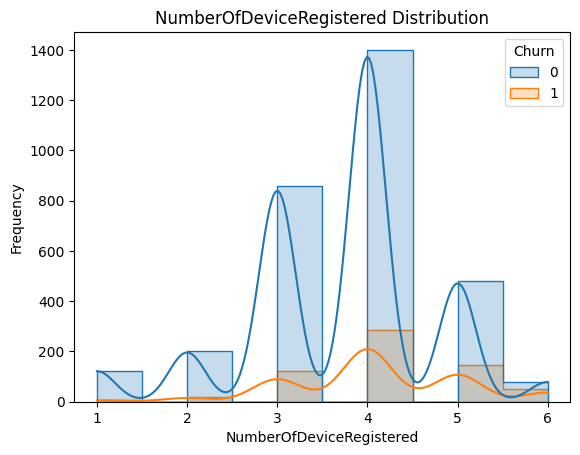

[10 more figures not shown]

```python
# Plot distribution of features
plt.figure(figsize=(15, 10))
for i, feature in enumerate(data.columns, 1):
    plt.subplot(5, 4, i)
    plt.hist(data[feature], bins=50, alpha=0.5, color='red', label=feature)
    plt.title(f'Distribution of {feature}')
    plt.xlabel(f'{feature}')
    plt.ylabel('Frequency')
    plt.legend()
plt.tight_layout()
plt.show()

# Correlation matrix
data_num = data.select_dtypes(include=np.number)
plt.figure(figsize=(18, 18))
sns.heatmap(data_num.corr(), annot=True, cmap='coolwarm', fmt=".2f", linewidths=0.5)
plt.title('Correlation Matrix')
plt.show()

# Distribution of numerical features by churn
for feature in data_num.columns:
    sns.histplot(data=data, x=feature, hue='Churn', bins=10, kde=True, element="step")
    plt.title(f"{feature} Distribution")
    plt.xlabel(feature)
    plt.ylabel("Frequency")
    plt.show()
```

```python
import pandas as pd
import numpy as np
from sklearn.feature_selection import SelectKBest, f_classif, chi2, RFE
from sklearn.linear_model import LogisticRegression
from sklearn.ensemble import RandomForestClassifier

def autoFeatureSelector(data, methods=['pearson', 'chi-square', 'rfe', 'log-reg', 'rf', 'anova'], num_feats=10):
    # Check if methods list is empty
    if not methods:
        raise ValueError("At least one feature selection method must be provided.")

    # Extract features and target variable
    numeric_columns = data.select_dtypes(include=np.number).columns.tolist()
    X = data[numeric_columns].drop('Churn', axis=1)
    y = data['Churn']

    # Clip values
    max_val = 5000
    X = np.clip(X, a_min=None, a_max=max_val)

    selected_features = []

    for method in methods:
        if method == 'pearson':
            # Calculate Pearson correlation coefficients
            pearson_corr = X.corrwith(y)
            cor_support = pearson_corr.abs().nlargest(num_feats).index
            selected_features.append(('Pearson', cor_support))

        elif method == 'chi-square':
            # Apply chi-square test to select features
            chi_selector = SelectKBest(score_func=chi2, k=num_feats)
            chi_selector.fit(X, y)
            chi_support = chi_selector.get_support(indices=True)
            selected_features.append(('Chi-2', X.columns[chi_support]))

        elif method == 'rfe':
            # Initialize the model
            model = LogisticRegression()
            # Apply Recursive Feature Elimination
            rfe_selector = RFE(estimator=model, n_features_to_select=num_feats, step=1)
            rfe_selector.fit(X, y)
            rfe_support = rfe_selector.get_support(indices=True)
            selected_features.append(('RFE', X.columns[rfe_support]))

        elif method == 'log-reg':
            # Initialize the model
            model = LogisticRegression()
            # Apply SelectFromModel with Logistic Regression as estimator
            embed_lr_selector = SelectFromModel(estimator=model, max_features=num_feats)
            embed_lr_selector.fit(X, y)
            embed_lr_support = embed_lr_selector.get_support(indices=True)
            selected_features.append(('Logistics', X.columns[embed_lr_support]))

        elif method == 'rf':
            # Initialize the model
            model = RandomForestClassifier()
            # Apply SelectFromModel with Random Forest as estimator
            embed_rf_selector = SelectFromModel(estimator=model, max_features=num_feats)
            embed_rf_selector.fit(X, y)
            embed_rf_support = embed_rf_selector.get_support(indices=True)
            selected_features.append(('Random Forest', X.columns[embed_rf_support]))

        elif method == 'anova':
            # Apply ANOVA test to select features
            anova_selector = SelectKBest(score_func=f_classif, k=num_feats)
            anova_selector.fit(X, y)
            anova_support = anova_selector.get_support(indices=True)
            selected_features.append(('ANOVA', X.columns[anova_support]))

    # Create DataFrame to store feature selection results
    feature_selection_df = pd.DataFrame({'Feature': X.columns})

    for method, support in selected_features:
        feature_selection_df[method] = feature_selection_df['Feature'].apply(lambda x: x in support)

    # Calculate total selected times for each feature
    feature_selection_df['Total'] = feature_selection_df.iloc[:, 1:].sum(axis=1)

    # Sort DataFrame based on total selected times
    feature_selection_df = feature_selection_df.sort_values(['Total', 'Feature'], ascending=False)

    # Get top num_feats features
    best_features = feature_selection_df.head(num_feats)

    return best_features
```

```python
# autoFeatureSelector fonksiyonunu çağırarak en iyi özellikleri alın
best_features = autoFeatureSelector(data, methods=['pearson', 'chi-square', 'rfe', 'log-reg', 'rf', 'anova'])

# En iyi özellikleri DataFrame'den alın
feature_list = best_features['Feature'].tolist()

# Özellikleri ekrana yazdırın
print("Selected Features:")
for feature in feature_list:
    print(feature)
```

[output not shown]

```
Selected Features:
Tenure
NumberOfAddress
Complain
SatisfactionScore
NumberOfDeviceRegistered
MaritalStatus
DaySinceLastOrder
WarehouseToHome
PreferedOrderCat
CityTier
```

### Model Training and Evaluation: Trains and evaluates Random Forest, XGBoost with hyperparameter tuning, K-Nearest Neighbors, and Logistic Regression models.

```python
# Özellik ve hedef değişkenleri belirleme
# data_col = [col for col in data.columns if col != 'CustomerID' and col != 'Churn']
# X = np.array(data[data_col])
# y = np.array(data['Churn'])
X = data[best_features['Feature']]
y = data['Churn']
# Eğitim ve test veri setlerini ayırma
train_ratio = 0.8
X_train, X_test, y_train, y_test = train_test_split(X, y, test_size=1 - train_ratio, shuffle=True, random_state=42)
```

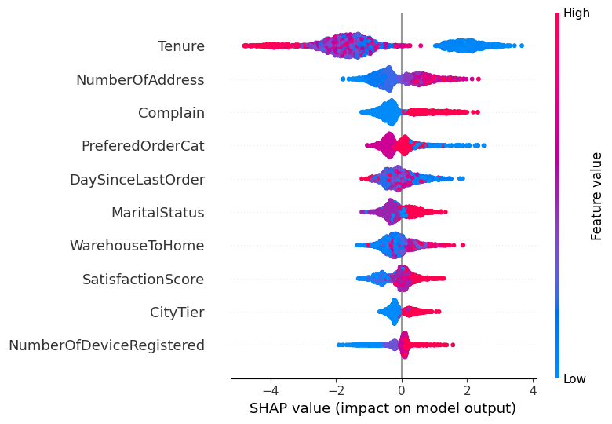

```python
# XGBoost modelini tanımlama ve eğitme
xgb_clf = XGBClassifier(learning_rate=0.1, n_estimators=100)
xgb_clf.fit(X_train, y_train)

# SHAP için TreeExplainer oluşturma ve görselleştirme
import shap
shap.initjs()
explainer = shap.TreeExplainer(xgb_clf)
shap_values = explainer.shap_values(X_train)
shap.summary_plot(shap_values, X_train)
```

```python
from sklearn.ensemble import RandomForestClassifier
from sklearn.metrics import accuracy_score, precision_score, recall_score, roc_auc_score, classification_report, confusion_matrix
# Random Forest Model
model_rf = RandomForestClassifier(n_estimators=100, random_state=42)
model_rf.fit(X_train, y_train)
y_pred_rf = model_rf.predict(X_test)

# Confusion Matrix
conf_matrix_rf = confusion_matrix(y_test, y_pred_rf)
print("Random Forest Confusion Matrix:")
print(conf_matrix_rf)

# Diğer Değerlendirme Metrikleri
accuracy_rf = accuracy_score(y_test, y_pred_rf)
precision_rf = precision_score(y_test, y_pred_rf)
recall_rf = recall_score(y_test, y_pred_rf)
roc_auc_rf = roc_auc_score(y_test, y_pred_rf)
class_report_rf = classification_report(y_test, y_pred_rf)
print(f'Accuracy: {accuracy_rf:.4f}')
print(f'Precision: {precision_rf:.4f}')
print(f'Recall: {recall_rf:.4f}')
print(f'ROC-AUC Score: {roc_auc_rf:.4f}')
print(f'Classification Report:\n{class_report_rf}')
```

```
Random Forest Confusion Matrix:
[[644   4]
 [ 19  88]]
Accuracy: 0.9695
Precision: 0.9565
Recall: 0.8224
ROC-AUC Score: 0.9081
Classification Report:
              precision    recall  f1-score   support

           0       0.97      0.99      0.98       648
           1       0.96      0.82      0.88       107

    accuracy                           0.97       755
   macro avg       0.96      0.91      0.93       755
weighted avg       0.97      0.97      0.97       755
```

```python
# XGBoost Model with Grid Search Best Estimator
param_grid = {'learning_rate': [0.1, 0.3], 'max_depth': [3, 5], 'n_estimators': [100, 200]}
grid_search = GridSearchCV(estimator=XGBClassifier(), param_grid=param_grid, cv=3, verbose=2)
grid_search.fit(X_train, y_train)

best_xgb_clf = grid_search.best_estimator_
y_pred_xgb = best_xgb_clf.predict(X_test)

# Confusion Matrix
conf_matrix_xgb = confusion_matrix(y_test, y_pred_xgb)
print("XGBoost Confusion Matrix:")
print(conf_matrix_xgb)

# Diğer Değerlendirme Metrikleri
accuracy_xgb = accuracy_score(y_test, y_pred_xgb)
precision_xgb = precision_score(y_test, y_pred_xgb)
recall_xgb = recall_score(y_test, y_pred_xgb)
roc_auc_xgb = roc_auc_score(y_test, y_pred_xgb)
class_report_xgb = classification_report(y_test, y_pred_xgb)
print(f'Accuracy: {accuracy_xgb:.4f}')
print(f'Precision: {precision_xgb:.4f}')
print(f'Recall: {recall_xgb:.4f}')
print(f'ROC-AUC Score: {roc_auc_xgb:.4f}')
print(f'Classification Report:\n{class_report_xgb}')
```

[output not shown]

```python
# K-Nearest Neighbors Model
knn_model = KNeighborsClassifier(n_neighbors=5)
knn_model.fit(X_train, y_train)
y_pred_knn = knn_model.predict(X_test)

# Confusion Matrix
conf_matrix_knn = confusion_matrix(y_test, y_pred_knn)
print("K-Nearest Neighbors Confusion Matrix:")
print(conf_matrix_knn)

# Diğer Değerlendirme Metrikleri
accuracy_knn = accuracy_score(y_test, y_pred_knn)
precision_knn = precision_score(y_test, y_pred_knn)
recall_knn = recall_score(y_test, y_pred_knn)
roc_auc_knn = roc_auc_score(y_test, y_pred_knn)
class_report_knn = classification_report(y_test, y_pred_knn)
print(f'Accuracy: {accuracy_knn:.4f}')
print(f'Precision: {precision_knn:.4f}')
print(f'Recall: {recall_knn:.4f}')
print(f'ROC-AUC Score: {roc_auc_knn:.4f}')
print(f'Classification Report:\n{class_report_knn}')
```

```
K-Nearest Neighbors Confusion Matrix:
[[633  15]
 [ 39  68]]
Accuracy: 0.9285
Precision: 0.8193
Recall: 0.6355
ROC-AUC Score: 0.8062
Classification Report:
              precision    recall  f1-score   support

           0       0.94      0.98      0.96       648
           1       0.82      0.64      0.72       107

    accuracy                           0.93       755
   macro avg       0.88      0.81      0.84       755
weighted avg       0.92      0.93      0.92       755
```

```python
# Logistic Regression with Lasso penalty
lasso = LogisticRegression(penalty='l1', solver='saga', max_iter=2000, n_jobs=-1)
lasso.fit(X_train, y_train)
y_pred_lr = lasso.predict(X_test)

# Confusion Matrix
conf_matrix_lr = confusion_matrix(y_test, y_pred_lr)
print("Logistic Regression Confusion Matrix:")
print(conf_matrix_lr)

# Diğer Değerlendirme Metrikleri
accuracy_lr = accuracy_score(y_test, y_pred_lr)
precision_lr = precision_score(y_test, y_pred_lr)
recall_lr = recall_score(y_test, y_pred_lr)
roc_auc_lr = roc_auc_score(y_test, y_pred_lr)
class_report_lr = classification_report(y_test, y_pred_lr)
print(f'Accuracy: {accuracy_lr:.4f}')
print(f'Precision: {precision_lr:.4f}')
print(f'Recall: {recall_lr:.4f}')
print(f'ROC-AUC Score: {roc_auc_lr:.4f}')
print(f'Classification Report:\n{class_report_lr}')
```

```
Logistic Regression Confusion Matrix:
[[632  16]
 [ 61  46]]
Accuracy: 0.8980
Precision: 0.7419
Recall: 0.4299
ROC-AUC Score: 0.7026
Classification Report:
              precision    recall  f1-score   support

           0       0.91      0.98      0.94       648
           1       0.74      0.43      0.54       107

    accuracy                           0.90       755
   macro avg       0.83      0.70      0.74       755
weighted avg       0.89      0.90      0.89       755
```

Here's the evaluation of the 4 models and the comparison of their performance:

### Model Evaluation and Comparison

#### Random Forest Model:

- **Confusion Matrix:**

- **Accuracy:** 0.9695
- **Precision:** 0.9565
- **Recall:** 0.8224
- **ROC-AUC Score:** 0.9081
- **Classification Report:**

  ```
          precision    recall  f1-score   support

       0       0.97      0.99      0.98       648
       1       0.96      0.82      0.88       107
  ```

  accuracy 0.97 755 macro avg 0.96 0.91 0.93 755

weighted avg 0.97 0.97 0.97 755

#### XGBoost Model:

- **Confusion Matrix:**

- **Accuracy:** 0.9576
- **Precision:** 0.8713
- **Recall:** 0.8224
- **ROC-AUC Score:** 0.9012
- **Classification Report:** precision recall f1-score support

  ```
       0       0.97      0.98      0.98       648
       1       0.87      0.82      0.85       107
  ```

  accuracy 0.96 755 macro avg 0.92 0.90 0.91 755

weighted avg 0.96 0.96 0.96 755

#### Logistic Regression Model:

- **Confusion Matrix:**

- **Accuracy:** 0.8980
- **Precision:** 0.7419
- **Recall:** 0.4299
- **ROC-AUC Score:** 0.7026
- **Classification Report:**

  ```
          precision    recall  f1-score   support

       0       0.91      0.98      0.94       648
       1       0.74      0.43      0.54       107
  ```

  accuracy 0.90 755 macro avg 0.83 0.70 0.74 755

weighted avg 0.89 0.90 0.89 755

#### K-Nearest Neighbors (KNN) Model:

- **Confusion Matrix:**

- **Accuracy:** 0.9285
- **Precision:** 0.8193
- **Recall:** 0.6355
- **ROC-AUC Score:** 0.8062
- **Classification Report:**

```
   0       0.94      0.98      0.96       648
   1       0.82      0.64      0.72       107
```

accuracy 0.93 755 macro avg 0.88 0.81 0.84 755 weighted avg 0.92 0.93 0.92 755

### Selected Features:

- **Tenure**
- **NumberOfAddress**
- **Complain**
- **SatisfactionScore**
- **NumberOfDeviceRegistered**
- **MaritalStatus**
- **DaySinceLastOrder**
- **WarehouseToHome**
- **PreferedOrderCat**
- **CityTier**

### Model Comparison:

- **Random Forest** shows the highest accuracy (0.9695) and precision (0.9565), indicating it makes fewer false positive predictions compared to XGBoost, Logistic Regression, and KNN.
- **XGBoost** has slightly lower accuracy and precision than Random Forest but performs well with an accuracy of 0.9576 and a precision of 0.8713.
- **K-Nearest Neighbors (KNN)** performs reasonably well with an accuracy of 0.9285 and a precision of 0.8193, although it has lower recall compared to Random Forest and XGBoost.
- **Logistic Regression** has the lowest accuracy (0.8980) and precision (0.7419), indicating it may not be as effective in correctly predicting churn as the tree-based models.

### Conclusion:

Based on the evaluation metrics, **Random Forest** emerges as the best-performing model for predicting churn in this dataset. It achieves the highest accuracy, precision, and ROC-AUC score among the evaluated models, making it the recommended choice for this prediction task.